# Segmentação Celular

Sysbiolab Team

Flávio Gabriel Carazza-Kessler

2026-09-08

# 1 Visão geral

Nesta vinheta, exploraremos limites celulares de um conjunto Xenium por meio da integração entre `RGraphSpace`, `sf` e `ggplot2` (Sysbiolab Team 2026). Cada célula será representada de duas formas complementares: como um vértice localizado no centro da célula e como o polígono correspondente à sua segmentação. A expressão de `Slc17a7` será projetada nas duas representações como exemplo de uso.

O roteiro foi adaptado da vinheta do Sysbiolab Team, [Spatial segmentation with RGraphSpace](https://sysbiolab.github.io/RGraphSpace/articles/spatial-segmentation1.html).

> **Importante:** esta análise não executa um novo algoritmo de segmentação sobre a imagem. Os limites celulares já foram estimados pelo processamento do Xenium; aqui, eles são carregados, inspecionados e utilizados como geometrias espaciais no `GraphSpace`.

Ao final, você será capaz de:

1. baixar e carregar o objeto `GraphSpace` preparado para o curso
2. acessar as geometrias celulares armazenadas no objeto
3. inspecionar células individuais e um conjunto de células
4. comparar a expressão representada nos centros e nos polígonos celulares

# 2 Origem e preparação dos dados

Os dados brutos do Xenium não serão baixados diretamente nesta atividade porque o arquivo compactado possui mais de **3 GB** e a importação completa exige tempo, memória e processamento consideráveis. Para tornar a atividade rápida e reproduzível, usaremos apenas a região previamente recortada e salva como um objeto leve.

A preparação completa está documentada na vinheta avançada [Instalação e preparação dos dados Xenium com RGraphSpace](https://flaviogckessler.github.io/Curso_ST/vinhetas/Instalacao_dados_Xenium_RGraphSpace.html), disponível no repositório do curso. Nela, os dados brutos são baixados, carregados pelo Seurat, convertidos para `GraphSpace`, associados aos polígonos celulares, orientados e recortados.

O objeto resultante está versionado no repositório do curso: [fonte de Xenium_GS_Crop.RDS no GitHub](https://github.com/flaviogckessler/Curso_ST/blob/main/data/Xenium_GS_Crop.RDS). O bloco de download desta vinheta utiliza o endereço direto desse arquivo.

# 3 Preparar o ambiente

## 3.1 Definir as pastas

Antes de executar o código, defina o diretório de trabalho como a pasta `vinhetas/`. No RStudio, use **Session > Set Working Directory > To Source File Location**. O objeto baixado será mantido em `data/`.

```
Curso_ST/
|-- imagens/
`-- data/
     `-- Xenium_GS_Crop.RDS
```

```r
diretorio_vinhetas <- getwd()
diretorio_curso <- dirname(diretorio_vinhetas)
diretorio_imagens <- file.path(diretorio_curso, "imagens")
diretorio_dados <- file.path(diretorio_curso, "data")

dir.create(diretorio_dados, showWarnings = FALSE, recursive = TRUE)
```

## 3.2 Conferir os pacotes necessários

A instalação dos pacotes do curso está centralizada em [Configuracao_do_ambiente_RStudio.Rmd](https://flaviogckessler.github.io/Curso_ST/vinhetas/Configuracao_do_ambiente_RStudio.html). Depois de executar a vinheta e reiniciar a sessão do R, use o bloco abaixo para confirmar que o ambiente está pronto.

```r
pacotes_segmentacao <- c(
  "RGraphSpace", "Seurat", "SeuratObject", "sf", "ggplot2", "patchwork")

pacotes_ausentes <- pacotes_segmentacao[
  !vapply(pacotes_segmentacao, requireNamespace, logical(1), quietly = TRUE)]

if (length(pacotes_ausentes) > 0) {
  stop("Execute primeiro Configuracao_do_ambiente_RStudio.Rmd. ",
    "Pacotes ausentes: ",paste(pacotes_ausentes, collapse = ", "))}
```

## 3.3 Carregar os pacotes

```r
library("RGraphSpace")
library("Seurat")
library("SeuratObject")
library("sf")
library("ggplot2")
library("patchwork")
```

# 4 Baixar e carregar o objeto preparado

O download é realizado somente quando o arquivo ainda não existe em `data/`.

```r
url_dados <- paste0(
  "https://raw.githubusercontent.com/flaviogckessler/Curso_ST/",
  "main/data/Xenium_GS_Crop.RDS")

arquivo_dados <- file.path(diretorio_dados, "Xenium_GS_Crop.RDS")

if (!file.exists(arquivo_dados)) {
  utils::download.file(url_dados,arquivo_dados,mode = "wb")}

gs_crop <- readRDS(arquivo_dados)

if (!inherits(gs_crop, "GraphSpace")) {
  stop("O arquivo baixado não contém um objeto da classe GraphSpace.")}

gs_crop
```

```
#> A GraphSpace-class object for:
#> IGRAPH e9b3d4d UN-- 2654 0 --
#> + attr: x (v/n), y (v/n), name (v/c), nodeLabel (v/c), nodeSize (v/n),
#> | cell (v/c), orig.ident (v/x), nCount_Xenium (v/n), nFeature_Xenium
#> | (v/n), segmentation_method (v/c), nCount_BlankCodeword (v/n),
#> | nFeature_BlankCodeword (v/n), nCount_ControlCodeword (v/n),
#> | nFeature_ControlCodeword (v/n), nCount_ControlProbe (v/n),
#> | nFeature_ControlProbe (v/n), arrowType (e/n)
#> + node payload: 1 (geometry)
#> + features: 248 (2010300C02Rik, Acsbg1, Acta2, Acvrl1, ...)
#> + samples: 2654 (2171, 2172, ...)
#> + node spatial boundaries: normalized to graph space
#> | x: [2579, 3623] -> [0, 1] (cols)
#> | y: [2118, 3161] -> [0, 1] (rows)
```

# 5 Inspecionar as geometrias celulares

Os polígonos estão armazenados como uma coleção de geometrias simples do pacote `sf`. Cada posição da coleção corresponde a uma célula e está alinhada ao respectivo vértice do `GraphSpace`.

```r
gs_crop@nodes$geometry
```

```
#> Geometry set for 2654 features
#> Geometry type: GEOMETRY
#> Dimension:     XY
#> Bounding box:  xmin: -0.01237423 ymin: -0.01132385 xmax: 1.015081 ymax: 1.015722
#> CRS:           NA
#> First 5 geometries:
#> POLYGON ((0.2253266 0.6889345, 0.2281807 0.6838...
#> POLYGON ((0.2402083 0.6836343, 0.243674 0.68261...
#> POLYGON ((0.1908744 0.6858766, 0.1998441 0.6826...
#> POLYGON ((0.2075907 0.6864882, 0.2077947 0.6852...
#> POLYGON ((0.1710999 0.6842458, 0.1745656 0.6838...
```

```r
geometrias_celulares <- gs_crop@nodes$geometry

length(geometrias_celulares)
```

```
#> [1] 2654
```

```r
sf::st_geometry_type(geometrias_celulares) |> table()
```

```
#>
#>           GEOMETRY              POINT         LINESTRING            POLYGON
#>                  0                  0                  0               2652
#>         MULTIPOINT    MULTILINESTRING       MULTIPOLYGON GEOMETRYCOLLECTION
#>                  0                  0                  2                  0
#>     CIRCULARSTRING      COMPOUNDCURVE       CURVEPOLYGON         MULTICURVE
#>                  0                  0                  0                  0
#>       MULTISURFACE              CURVE            SURFACE  POLYHEDRALSURFACE
#>                  0                  0                  0                  0
#>                TIN           TRIANGLE
#>                  0                  0
```

## 5.1 Visualizar células individuais

Para exemplificar, as três primeiras geometrias são mostradas separadamente. O contorno preserva a forma e a área estimadas para cada célula, enquanto sua posição permanece no sistema de coordenadas normalizado durante a preparação dos dados.

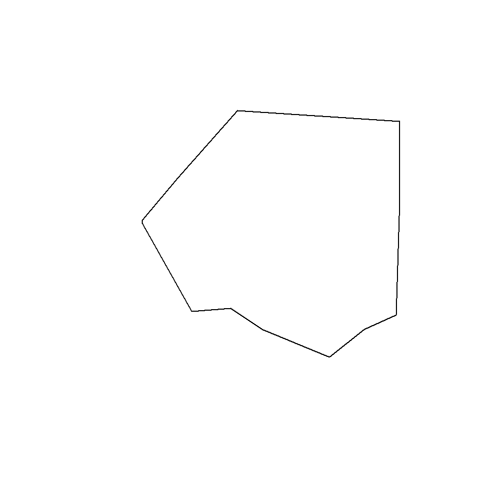

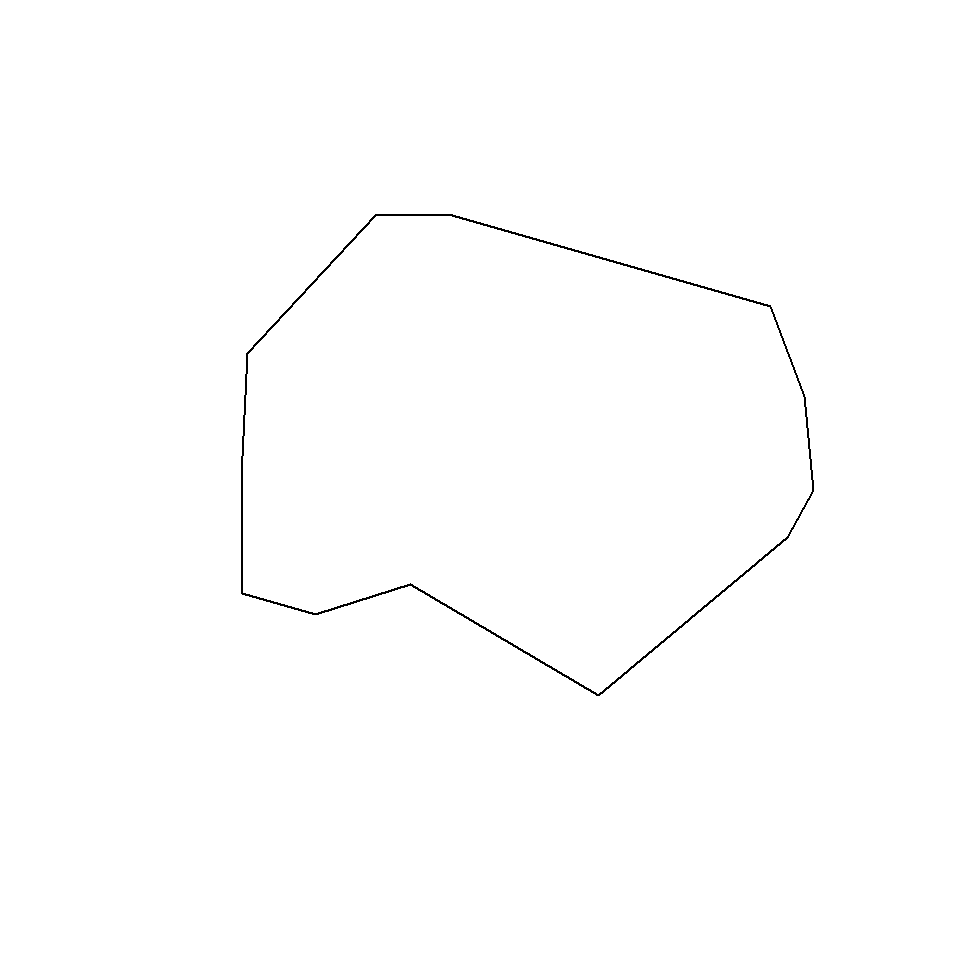

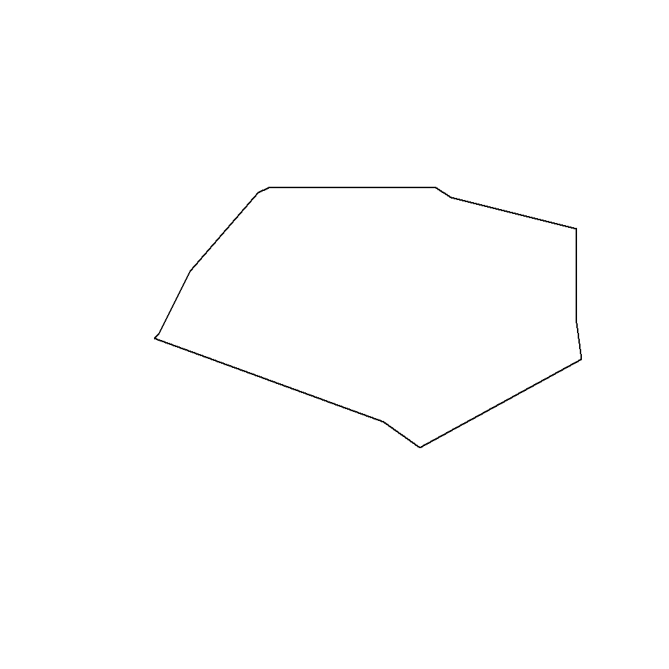

```r
plot(gs_crop@nodes$geometry[1])
plot(gs_crop@nodes$geometry[2])
plot(gs_crop@nodes$geometry[3])
```

## 5.2 Combinar as primeiras vinte geometrias

`st_combine()` reúne as geometrias em uma única coleção sem dissolver os limites entre células. Assim, os vinte contornos continuam reconhecíveis no mesmo painel.

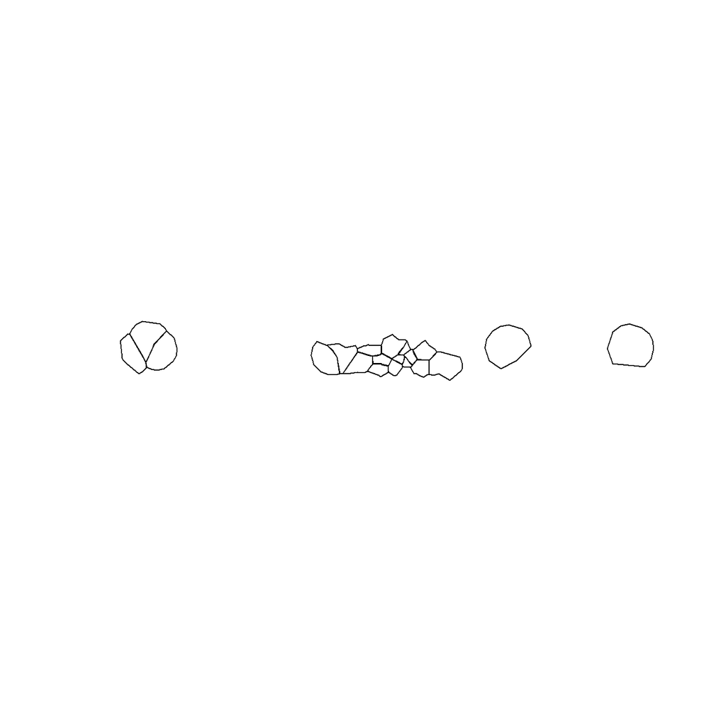

```r
plot(st_combine(gs_crop@nodes$geometry[1:20]))
```

# 6 Comparar centros e polígonos celulares

Para que os dois painéis sejam comparáveis, ambos utilizam a transformação `log2(x + 1)`, a mesma paleta e os mesmos limites de escala para a expressão de `Slc17a7`.

```r
cpal <- hcl.colors(100, palette = "Geyser", rev = FALSE)
data_range <- range(log2(gs_crop[["fdata"]] + 1))
```

## 6.1 Representar as células como vértices

No primeiro painel, cada célula é representada por um ponto localizado em seu centro. Essa forma compacta facilita a inspeção da distribuição espacial geral, mas não mostra o contorno celular.

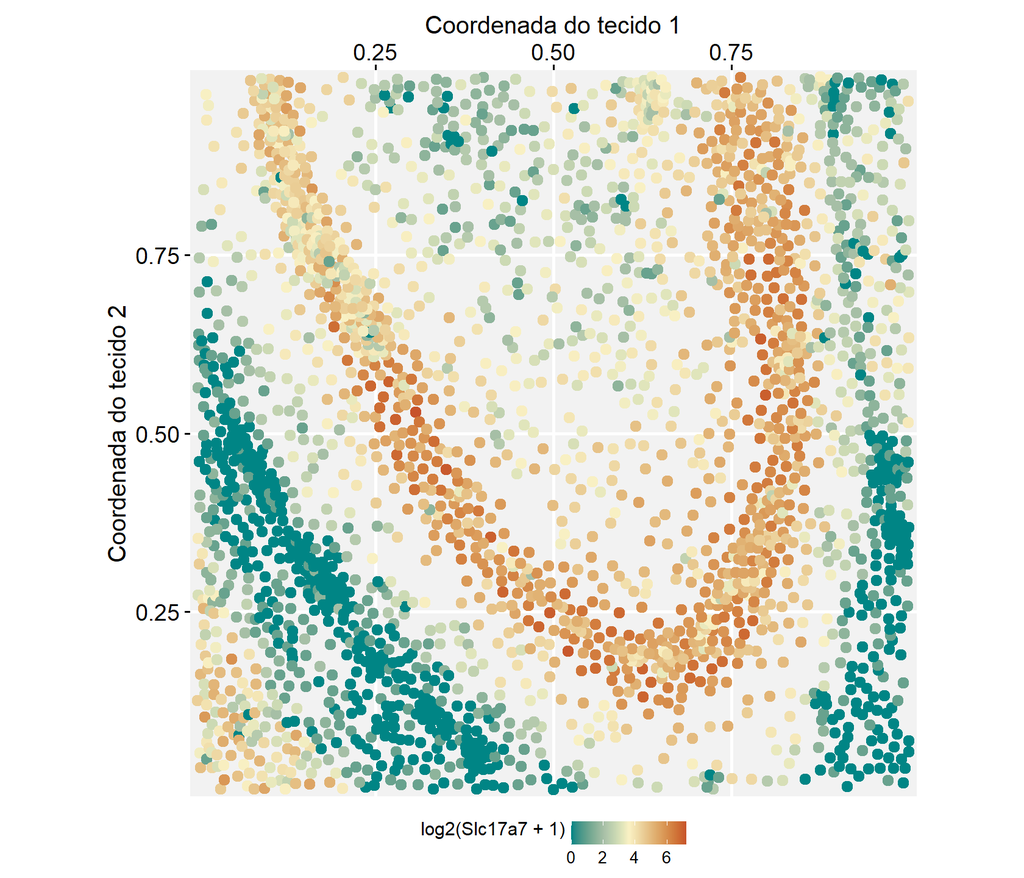

```r
p1 <- ggplot(gs_crop) +
  geom_nodespace(
    mapping = aes(colour = log2(Slc17a7 + 1)),
    size = 1.5,pch = 19) +
  scale_colour_continuous(palette = cpal, limits = data_range) +
  theme_gspace_coords(
    theme = "th3",is_norm = TRUE,
    xlab = "Coordenada do tecido 1",
    ylab = "Coordenada do tecido 2")

p1
```